# Pertemuan 4 - Model AR, MA, ARMA

Akmal Basis Jatining Kusumah

## Pembangkitan Proses MA(2)

```r
set.seed(036)
wn <- rnorm(300)
ma <- wn[c(1,2)]
ma
```

```
## [1] 0.3117314 0.8498291
```

```r
for(i in 3:300){
   ma[i] <- wn[i] + 0.4 * wn[i - 1] + 0.6 * wn[i - 2]
}
ma
```

```
##   [1]  0.311731381  0.849829114  1.232503600  2.492039155 -0.242279721
##   [6] -0.088084716 -0.975716210 -1.752956693 -0.341931207 -0.755682469
##  [11] -0.367011574 -0.622877136 -0.015216713  1.346906327  0.851739969
##  [16]  0.992419668  1.114952460 -0.006507128  0.750606864 -0.668034340
##  [21]  1.520132697 -0.669359411  1.959054019 -1.192747866 -0.374697584
##  [26]  0.706522754 -1.712962355  1.585996343  0.122865237  0.679181810
##  [31] -0.155147823 -1.186537277  0.909927739 -0.518656290  1.530064203
##  [36] -1.135146049  1.273140014  0.011374598  1.397430220 -1.128999479
##  [41]  0.517548719 -0.917448406 -0.219507834  0.252798044  0.208795878
##  [46]  0.817234333  0.392515753  2.405560415  1.277955706  1.547415200
##  [51]  1.267786699  0.511673100  0.673734533  0.495266664 -0.461475139
##  [56]  0.280583606  0.255281746 -2.128424999 -1.021282520 -2.396137405
##  [61] -0.193900182  0.316267144 -0.066765231  0.277622903 -1.538067104
##  [66]  0.324148212 -0.819714520  1.106022131  0.754763483  0.082145436
##  [71]  0.599073767 -0.336765258 -0.012411925 -0.786225786 -0.890850165
```

[output cut: 45 more lines]

```r
ma2 <- arima.sim(list(order=c(0,0,2), ma=c(0.4,0.6)), n=300)
ma2
```

```
## Time Series:
## Start = 1
## End = 300
## Frequency = 1
##   [1]  0.535067817 -0.399354327  0.441907815  0.616839764 -0.159898743
##   [6]  0.702383565  1.490325256  0.118915318 -0.047166900 -1.813084596
##  [11] -1.471898008 -1.826767789 -0.383049029 -0.284741279 -1.776416861
##  [16] -1.260813970 -1.396312050 -3.980711918 -0.893432816 -3.147190503
##  [21] -0.664291017 -0.342103252 -1.400570052 -0.632391065 -2.121505683
##  [26] -0.148403752  0.802294941  0.912851181  3.247699803  0.509346112
##  [31]  4.608945667  1.844499486  1.975024794  0.018703251 -0.386976376
##  [36] -0.135248885  0.222257550 -0.238074979 -0.244889148 -0.687452251
##  [41] -2.271762680 -0.594448963 -0.060010486 -0.622920188  1.508587770
##  [46] -0.803673796  1.565218513 -0.489485047  0.308189895 -0.621941469
##  [51] -0.506378000 -1.084497453 -1.343477122 -0.957288387 -1.300709072
```

[output cut: 49 more lines]

## Karakteristik MA(2)

### Plot Time Series

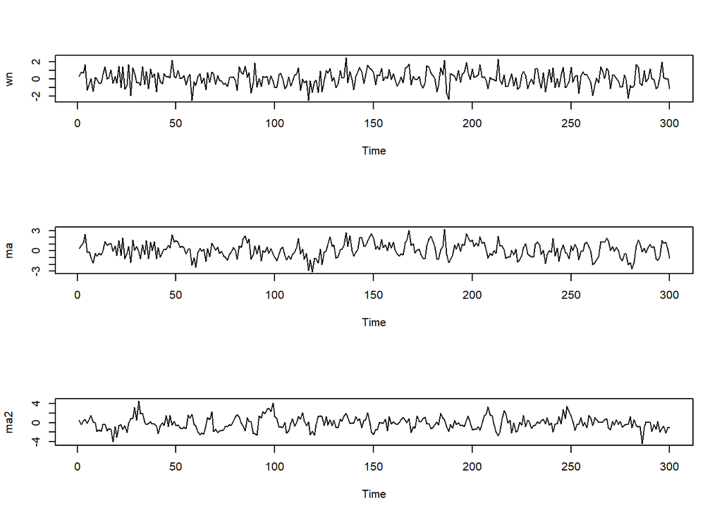

```r
par(mfrow = c(3, 1))
ts.plot(wn)
ts.plot(ma)
ts.plot(ma2)
```

Berdasarkan plot time series, terlihat bahwa data MA(2) yang dibangkitkan stasioner dalam rataan

### Plot ACF

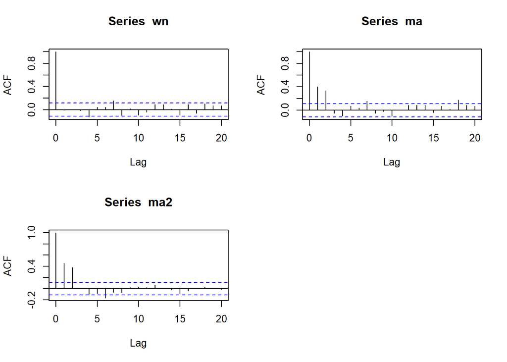

```r
par(mfrow = c(2,2))
acf(wn, lag.max = 20)
acf(ma,lag.max = 20)
acf(ma2,lag.max = 20)
```

### Plot PACF

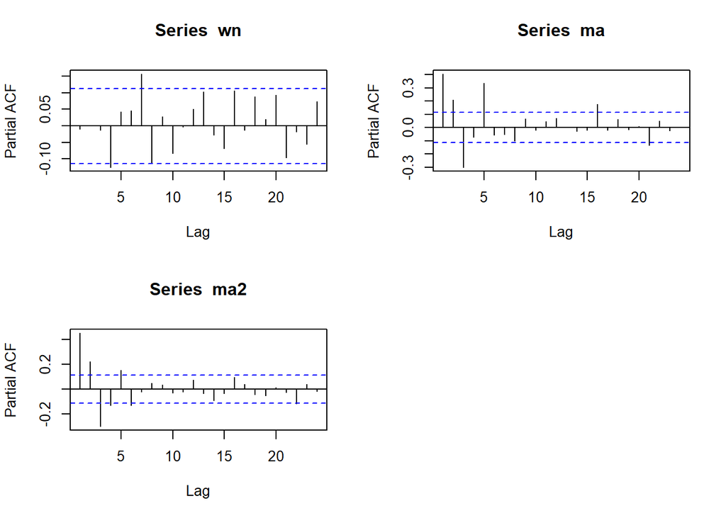

```r
par(mfrow = c(2,2))
pacf(wn)
pacf(ma)
pacf(ma2)
```

Berdasarkan plot PACF tersebut, terlihat bahwa plot PACF cenderung *tails off* dan membentuk gelombang sinus

### Plot EACF

```r
TSA::eacf(wn)
```

```
## AR/MA
##   0 1 2 3 4 5 6 7 8 9 10 11 12 13
## 0 o o o x o o x o o o o  o  o  o
## 1 o o o o o o x o o o o  o  o  o
## 2 o o o o o o x o o o o  o  o  o
## 3 o o o o o o o o o o o  o  o  o
## 4 x x x o o o o o o o o  o  o  o
## 5 x o x o o o o o o o o  o  o  o
## 6 x x x x o x o o o o o  o  o  o
## 7 x x x x o x x o o o o  o  o  o
```

```r
TSA::eacf(ma)
```

```
## AR/MA
##   0 1 2 3 4 5 6 7 8 9 10 11 12 13
## 0 x x o o o o x o o o o  o  o  o
## 1 x x x o x o x x o o o  o  o  o
## 2 x x x o o o x o o o o  o  o  o
## 3 x x o o x o o o o o o  o  o  o
## 4 x x o x x o o o o o o  o  o  o
## 5 x x x o x o x o o o o  o  o  o
## 6 x o x x o o x o o o o  o  o  o
## 7 x x x o x o x o o o o  o  o  o
```

```r
TSA::eacf(ma2)
```

```
## AR/MA
##   0 1 2 3 4 5 6 7 8 9 10 11 12 13
## 0 x x o o o x o o o o o  o  o  o
## 1 x x o o o x o o o o o  o  o  o
## 2 x x x x o x o o o o o  o  o  o
## 3 x x x x x o o o o o o  o  o  o
## 4 x o x o x o o o o o o  o  o  o
## 5 x x x o x o x o o o o  o  o  o
## 6 x x x o o o o o o o o  o  o  o
## 7 x x x o o x o o o o o  o  o  o
```

Berdasarkan pola segitiga nol pada plot EACF, terlihat bahwa segitiga nol berada pada ordo AR(0) dan ordo MA(2)

### Scatterplot Antar Lag

#### Korelasi antara $Y_t$ dengan $Y_{t-1}$

```r
#Yt
yt_ma <- ma[-1]
head(yt_ma)
```

```
## [1]  0.84982911  1.23250360  2.49203916 -0.24227972 -0.08808472 -0.97571621
```

```r
#Yt-1
yt_1_ma <- ma[-300]
head(yt_1_ma)
```

```
## [1]  0.31173138  0.84982911  1.23250360  2.49203916 -0.24227972 -0.08808472
```

```r
#Yt
yt_ma2 <- ma2[-1]
head(yt_ma2)
```

```
## [1] -0.3993543  0.4419078  0.6168398 -0.1598987  0.7023836  1.4903253
```

```r
#Yt-1
yt_1_ma2 <- ma2[-300]
head(yt_1_ma2)
```

```
## [1]  0.5350678 -0.3993543  0.4419078  0.6168398 -0.1598987  0.7023836
```

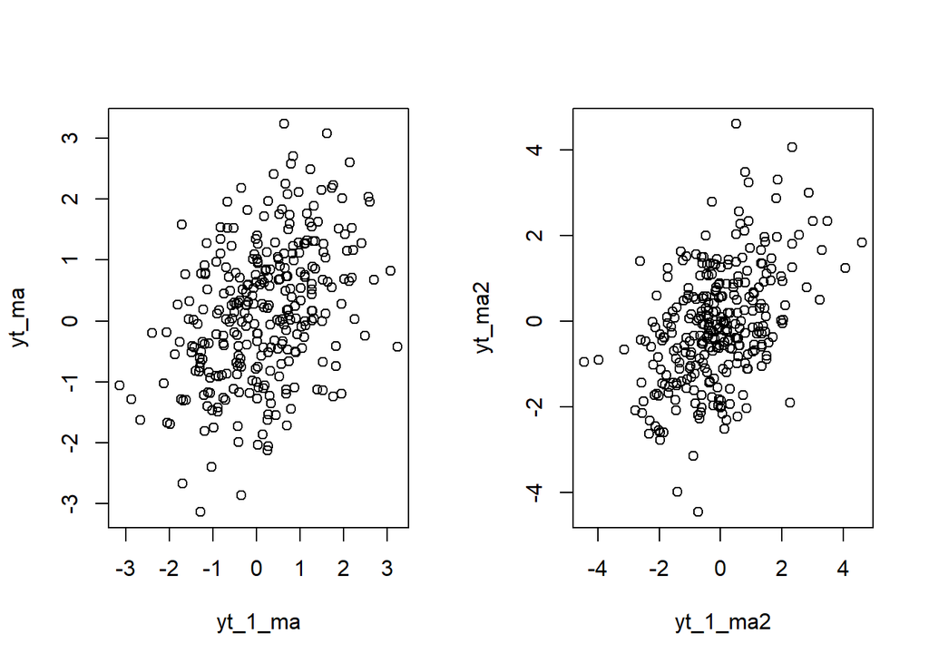

```r
par(mfrow = c(1,2))
plot(y=yt_ma,x=yt_1_ma)
plot(y=yt_ma2,x=yt_1_ma2)
```

```r
cor(yt_ma,yt_1_ma)
```

```
## [1] 0.4046046
```

```r
cor(yt_ma2,yt_1_ma2)
```

```
## [1] 0.4528889
```

#### Korelasi antara $Y_t$ dengan $Y_{t-2}$

```r
#Yt
yt2_ma <- ma[-c(1,2)]
head(yt2_ma)
```

```
## [1]  1.23250360  2.49203916 -0.24227972 -0.08808472 -0.97571621 -1.75295669
```

```r
#Yt-1
yt2_1_ma <- ma[-c(299,300)]
head(yt2_1_ma)
```

```
## [1]  0.31173138  0.84982911  1.23250360  2.49203916 -0.24227972 -0.08808472
```

```r
#Yt
yt2_ma2 <- ma2[-c(1,2)]
head(yt2_ma2)
```

```
## [1]  0.4419078  0.6168398 -0.1598987  0.7023836  1.4903253  0.1189153
```

```r
#Yt-1
yt2_1_ma2 <- ma2[-c(299,300)]
head(yt2_1_ma2)
```

```
## [1]  0.5350678 -0.3993543  0.4419078  0.6168398 -0.1598987  0.7023836
```

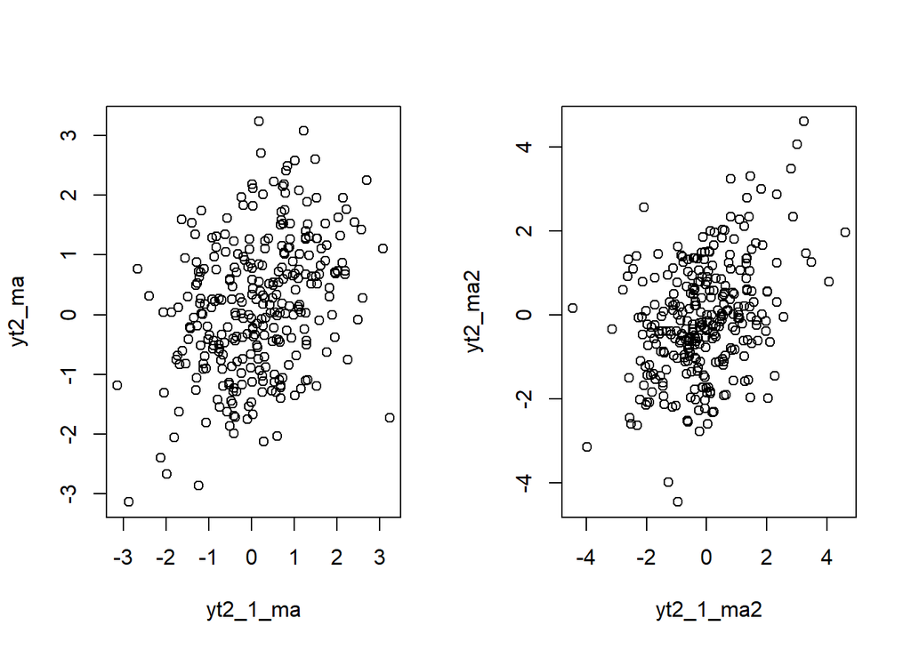

```r
par(mfrow = c(1,2))
plot(y=yt2_ma,x=yt2_1_ma)
plot(y=yt2_ma2,x=yt2_1_ma2)
```

```r
cor(yt2_ma,yt2_1_ma)
```

```
## [1] 0.3378477
```

```r
cor(yt2_ma2,yt2_1_ma2)
```

```
## [1] 0.3803097
```

#### Korelasi antara $Y_t$ dengan $Y_{t-3}$

```r
#Yt
yt3_ma <- ma[-c(1,2,3)]
head(yt3_ma)
```

```
## [1]  2.49203916 -0.24227972 -0.08808472 -0.97571621 -1.75295669 -0.34193121
```

```r
#Yt-1
yt3_1_ma <- ma[-c(298,299,300)]
head(yt3_1_ma)
```

```
## [1]  0.31173138  0.84982911  1.23250360  2.49203916 -0.24227972 -0.08808472
```

```r
#Yt
yt3_ma2 <- ma2[-c(1,2,3)]
head(yt3_ma2)
```

```
## [1]  0.6168398 -0.1598987  0.7023836  1.4903253  0.1189153 -0.0471669
```

```r
#Yt-1
yt3_1_ma2 <- ma2[-c(298,299,300)]
head(yt3_1_ma2)
```

```
## [1]  0.5350678 -0.3993543  0.4419078  0.6168398 -0.1598987  0.7023836
```

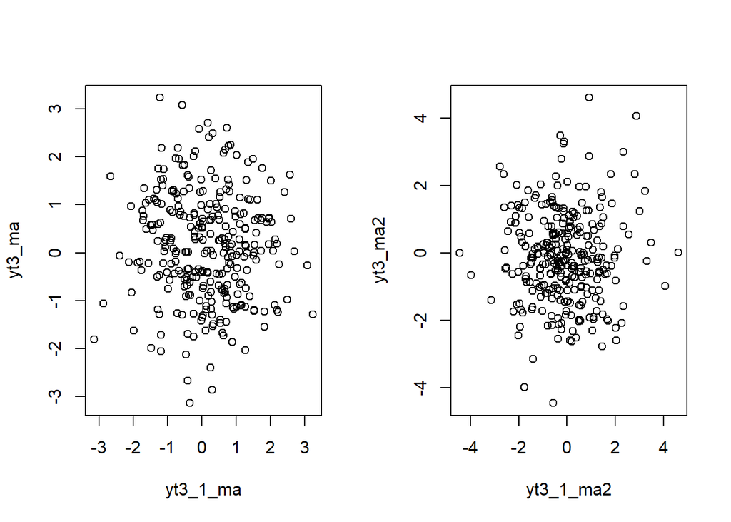

```r
par(mfrow = c(1,2))
plot(y=yt3_ma,x=yt3_1_ma)
plot(y=yt3_ma2,x=yt3_1_ma2)
```

```r
cor(yt3_ma,yt3_1_ma)
```

```
## [1] -0.0505656
```

```r
cor(yt3_ma2,yt3_1_ma2)
```

```
## [1] 0.005942738
```

## Pembangkitan Proses AR(2)

```r
n<-length(wn)
n
```

```
## [1] 300
```

```r
ar <- c(1:n)
for (i in 3:n) {ar[i]<-wn[i]+0.5*ar[i-1]+0.2*ar[i-2]}
ar
```

```
##   [1]  1.00000000  2.00000000  1.90553313  3.05269500  0.56188315  0.32166719
##   [7]  0.33276195 -1.20417494 -0.33924158 -0.38372204 -0.75519050 -0.89506457
##  [13] -0.14020843  1.17887936  0.56692219  0.65264906  1.49798207  0.36965722
##  [19]  0.80401348 -0.01401336  1.67815626 -0.14885712  1.69969360 -0.35698931
##  [25] -0.60552219  1.34538911 -1.38901171  0.90508020  0.92976080  0.22476409
##  [31] -0.14137450 -0.78370882  1.05681341 -0.28298381  0.97562885 -0.67344237
##  [37]  1.02995377  0.58583935  1.11119076 -0.82447892  0.55907608 -0.20409180
##  [43] -0.53169133  0.35395871  0.34006426  0.55391530  0.45059578  2.51153640
##  [49]  1.69028571  1.45183272  2.08336815  1.37333631  1.14892525  1.30139175
##  [55]  0.21075096  0.64277230  0.90980868 -1.92974622 -1.12667529 -1.69999572
##  [61] -0.76269122 -0.07970899 -0.70339729 -0.27059718 -1.54625972 -0.05321438
##  [67] -0.70301862  0.42631279  0.73222586 -0.20342733  0.50992249  0.08431582
##  [73] -0.09540013 -0.64326970 -0.84286640 -1.40550202 -0.66716478 -0.41930625
##  [79] -0.07036012 -0.33107203 -1.52857833  0.60895496  0.75579865  1.09010861
##  [85]  2.23029617  1.52313591  1.97849280 -0.36678916 -0.21134332  1.70960586
```

[output cut: 35 more lines]

```r
ar2 <- arima.sim(list(order=c(2,0,0), ar=c(0.5,0.2)), n=300)
ar2
```

```
## Time Series:
## Start = 1
## End = 300
## Frequency = 1
##   [1]  0.55838117  0.22014231 -0.81586891  0.81539209  0.02598765 -0.09404183
##   [7] -0.92033414 -0.77806286 -1.02777654 -0.92617863  0.06412151 -1.88293349
##  [13] -2.08680274 -0.52542491 -0.80007306 -0.93310113 -0.56521528  0.19993716
##  [19] -0.61271194 -0.33256981 -1.11433727 -0.32608280 -0.26999877  0.13046663
##  [25] -0.21784213 -0.79827036 -1.36932261 -0.37964719 -1.73651318 -0.89788565
##  [31] -0.11238207  1.81458043  2.68563248  0.28913662 -0.57914546  0.04194179
##  [37] -1.26830339 -1.59683831 -2.71471049 -1.17640677 -2.16332743 -2.45829249
##  [43] -2.22830543 -1.00348039 -0.88945863 -0.72665704 -0.53092343 -0.70707600
##  [49]  1.38714824  0.30668226  0.85986616  1.60918573  1.03224292 -0.07980174
##  [55] -0.39533425  0.36739640  1.07490565 -0.03238632 -1.26519700 -0.13829617
##  [61] -0.07937077  0.11040518 -0.25327248 -1.60378349 -0.58715465 -0.85793352
```

[output cut: 39 more lines]

## Karakteristik AR(2)

### Plot Time Series

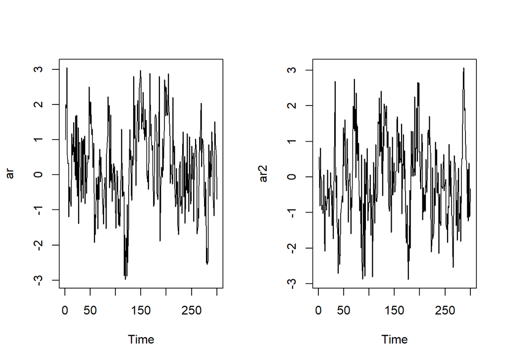

```r
par(mfrow = c(1,2))
ts.plot(ar)
ts.plot(ar2)
```

Berdasarkan plot time series tersebut terlihat bahwa data cenderung stasioner pada rataan

### Plot ACF

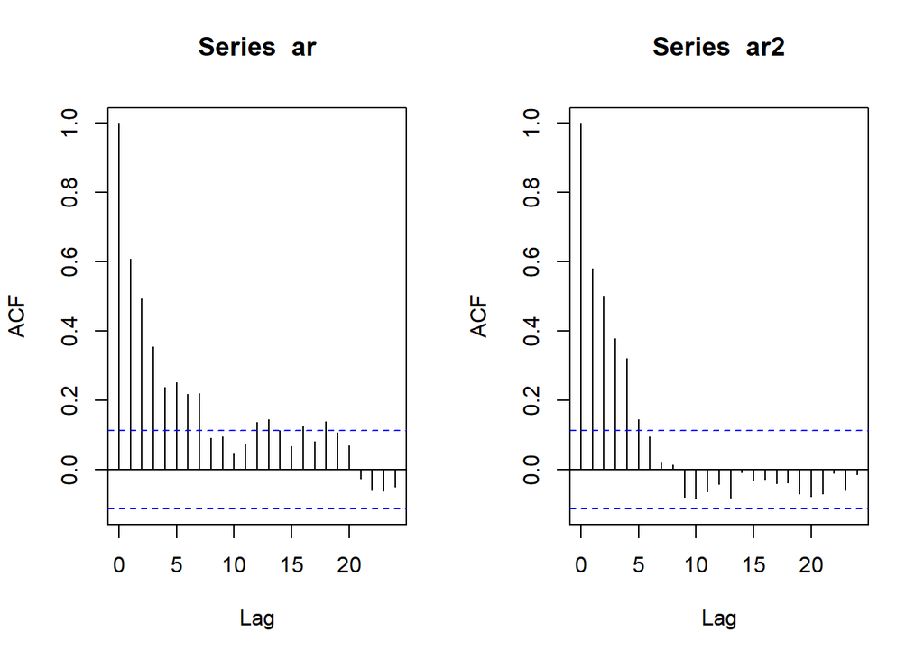

```r
par(mfrow = c(1,2))
acf(ar)
acf(ar2)
```

Berdasarkan plot ACF tersebut terlihat bahwa plot ACF cenderung *tails off* dan cenderung untuk menurun dengan perlahan.

### Plot PACF

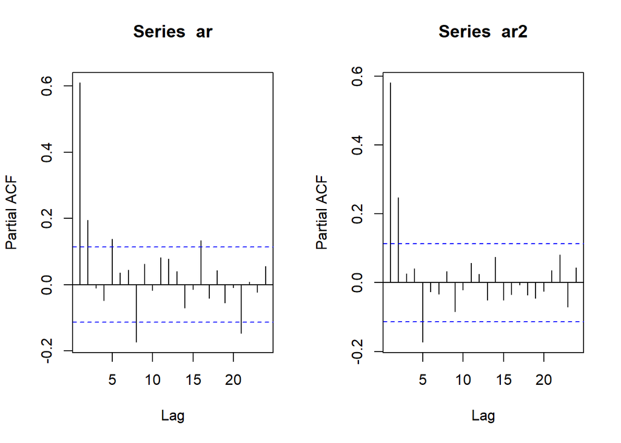

```r
par(mfrow =c(1,2))
pacf(ar)
pacf(ar2)
```

### Plot EACF

```r
TSA::eacf(ar)
```

```
## AR/MA
##   0 1 2 3 4 5 6 7 8 9 10 11 12 13
## 0 x x x x x x x o o o o  x  x  o
## 1 x o o x o o x x o o o  o  o  o
## 2 o x o x o o x o o o o  o  o  o
## 3 x o o x o o x o o x o  o  o  o
## 4 x x x x o o o o o x o  o  o  o
## 5 x x x x o o o x o o o  o  o  o
## 6 x o x x o o o x o o o  o  o  o
## 7 x x x x o o o x o o o  o  o  o
```

```r
TSA::eacf(ar2)
```

```
## AR/MA
##   0 1 2 3 4 5 6 7 8 9 10 11 12 13
## 0 x x x x x o o o o o o  o  o  o
## 1 x o o x o o o o o o o  o  o  o
## 2 o x o x o o o o o o o  o  o  o
## 3 x o x x o o o o o o o  o  o  o
## 4 x x x x o o o x o o o  o  o  o
## 5 x x x x o o o o o o o  o  o  o
## 6 x x o x x x o o o x o  o  o  o
## 7 x x o x o x o o o x o  o  o  o
```

Berdasarkan pola segitiga nol pada plot EACF, terlihat bahwa segitiga nol berada pada ordo AR(2) dan ordo MA(0)

### Scatterplot Antar Lag

#### Korelasi antara $Y_t$ dengan $Y_{t-1}$

```r
#Yt
yt_ar <- ar[-c(1)]
head(yt_ar)
```

```
## [1] 2.0000000 1.9055331 3.0526950 0.5618832 0.3216672 0.3327620
```

```r
#Yt-1
yt_1_ar <- ar[-c(300)]
head(yt_1_ar)
```

```
## [1] 1.0000000 2.0000000 1.9055331 3.0526950 0.5618832 0.3216672
```

```r
#Yt
yt_ar2 <- ar2[-c(1)]
head(yt_ar2)
```

```
## [1]  0.22014231 -0.81586891  0.81539209  0.02598765 -0.09404183 -0.92033414
```

```r
#Yt-1
yt_1_ar2 <- ar2[-c(300)]
head(yt_1_ar2)
```

```
## [1]  0.55838117  0.22014231 -0.81586891  0.81539209  0.02598765 -0.09404183
```

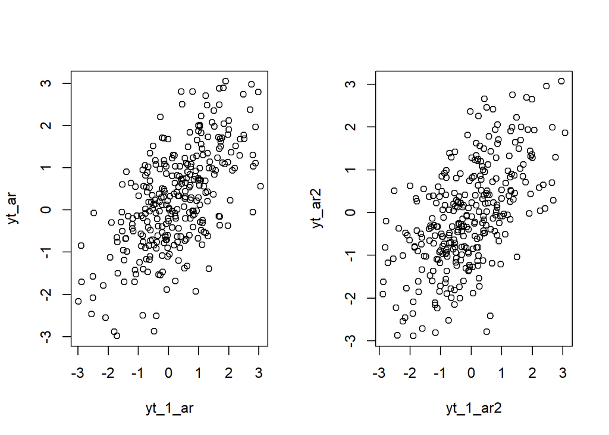

```r
par(mfrow = c(1,2))
plot(y=yt_ar,x=yt_1_ar)
plot(y=yt_ar2,x=yt_1_ar2)
```

```r
cor(yt_ar,yt_1_ar)
```

```
## [1] 0.6104916
```

```r
cor(yt_ar2,yt_1_ar2)
```

```
## [1] 0.5811887
```

#### Korelasi antara $Y_t$ dengan $Y_{t-2}$

```r
#Yt
yt2_ar <- ar[-c(1,2)]
head(yt2_ar)
```

```
## [1]  1.9055331  3.0526950  0.5618832  0.3216672  0.3327620 -1.2041749
```

```r
#Yt-1
yt2_1_ar <- ar[-c(299,300)]
head(yt2_1_ar)
```

```
## [1] 1.0000000 2.0000000 1.9055331 3.0526950 0.5618832 0.3216672
```

```r
#Yt
yt2_ar2 <- ar2[-c(1,2)]
head(yt2_ar2)
```

```
## [1] -0.81586891  0.81539209  0.02598765 -0.09404183 -0.92033414 -0.77806286
```

```r
#Yt-1
yt2_1_ar2 <- ar2[-c(299,300)]
head(yt2_1_ar2)
```

```
## [1]  0.55838117  0.22014231 -0.81586891  0.81539209  0.02598765 -0.09404183
```

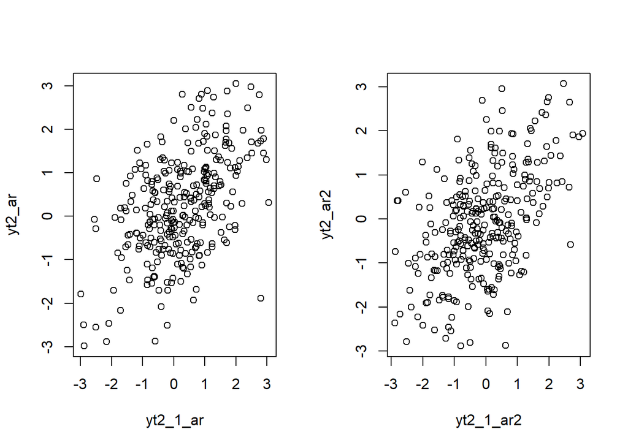

```r
par(mfrow = c(1,2))
plot(y=yt2_ar,x=yt2_1_ar)
plot(y=yt2_ar2,x=yt2_1_ar2)
```

```r
cor(yt2_ar,yt2_1_ar)
```

```
## [1] 0.4960805
```

```r
cor(yt2_ar2,yt2_1_ar2)
```

```
## [1] 0.5024356
```

#### Korelasi antara $Y_t$ dengan $Y_{t-3}$

```r
#Yt
yt3_ar <- ar[-c(1,2,3)]
head(yt3_ar)
```

```
## [1]  3.0526950  0.5618832  0.3216672  0.3327620 -1.2041749 -0.3392416
```

```r
#Yt-1
yt3_1_ar <- ar[-c(298,299,300)]
head(yt3_1_ar)
```

```
## [1] 1.0000000 2.0000000 1.9055331 3.0526950 0.5618832 0.3216672
```

```r
#Yt
yt3_ar2 <- ar2[-c(1,2,3)]
head(yt3_ar2)
```

```
## [1]  0.81539209  0.02598765 -0.09404183 -0.92033414 -0.77806286 -1.02777654
```

```r
#Yt-1
yt3_1_ar2 <- ar2[-c(298,299,300)]
head(yt3_1_ar2)
```

```
## [1]  0.55838117  0.22014231 -0.81586891  0.81539209  0.02598765 -0.09404183
```

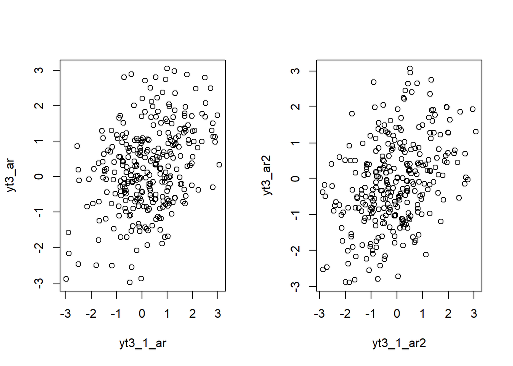

```r
par(mfrow = c(1,2))
plot(y=yt3_ar,x=yt3_1_ar)
plot(y=yt3_ar2,x=yt3_1_ar2)
```

```r
cor(yt3_ar,yt3_1_ar)
```

```
## [1] 0.3576777
```

```r
cor(yt3_ar2,yt3_1_ar2)
```

```
## [1] 0.3805339
```

## Pembangkitan ARMA(2,2)

```r
coefs <- c(0.6, 0.4, 0.5, 0.2)
e <- c(1, 2, 3, 4)

coefs %*% e
```

```
##      [,1]
## [1,]  3.7
```

```r
arma.sim <- function(n, macoef, arcoef){
  manum <- length(macoef)
  arnum <- length(arcoef)
  stopifnot(manum < n & arnum < n)

  wn <- rnorm(n, sd = 0.5)
  init <- max(manum, arnum)

  arma <- wn[1:init]
  for(i in {init+1}:n){
   mastart <- i - manum
   maend <- i-1
   arstart <- i - arnum
   arend <- i-1
   arma[i] <- sum(arcoef * arma[arstart:arend]) + sum(macoef * wn[mastart:maend])  + wn[i]
   }
  return(arma)
}
```

```r
arrma <- arma.sim(300,c(0.4,0.6),c(0.5,0.2))
head(arrma)
```

```
## [1] -0.8457423 -0.1359223 -0.5812568  0.7029762  0.5906725  1.4387427
```

```r
n = length(wn)
phi1 = 0.5
phi2 = 0.2
theta1 = 0.4
theta2 = 0.6

y.arma <- c(1:n)
for (i in 3:n){y.arma[i] = phi1*y.arma[i-1] + theta1*wn[i-1] + phi2*y.arma[i-2] + theta2*wn[i-2] + wn[i]}
head(y.arma)
```

```
## [1] 1.000000 2.000000 2.432504 4.108291 2.298366 1.882757
```

```r
arma22 <- arima.sim(list(order=c(2,0,2), ar = c(0.5,0.2), ma = c(0.4,0.6)), n=300)
head(arma22)
```

```
## [1] 3.929181 3.475154 3.404649 3.608189 1.284828 2.135939
```

### Plot Time Series

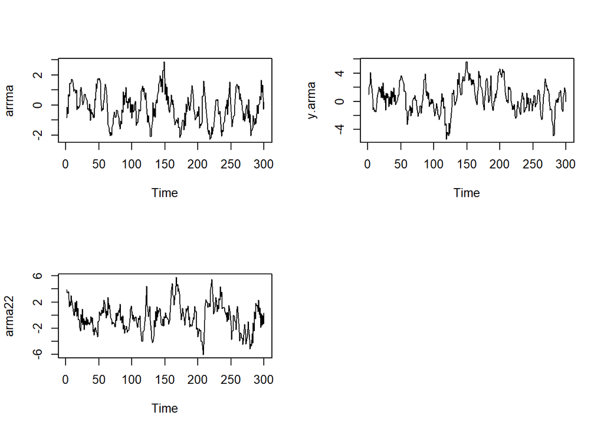

```r
par(mfrow = c(2, 2))
ts.plot(arrma)
ts.plot(y.arma)
ts.plot(arma22)
par(mfrow = c(1, 1))
```

Berdasarkan plot time series di atas dapat dilihat bahwa data pada arma22 stasioner dalam rataan.

### Plot ACF

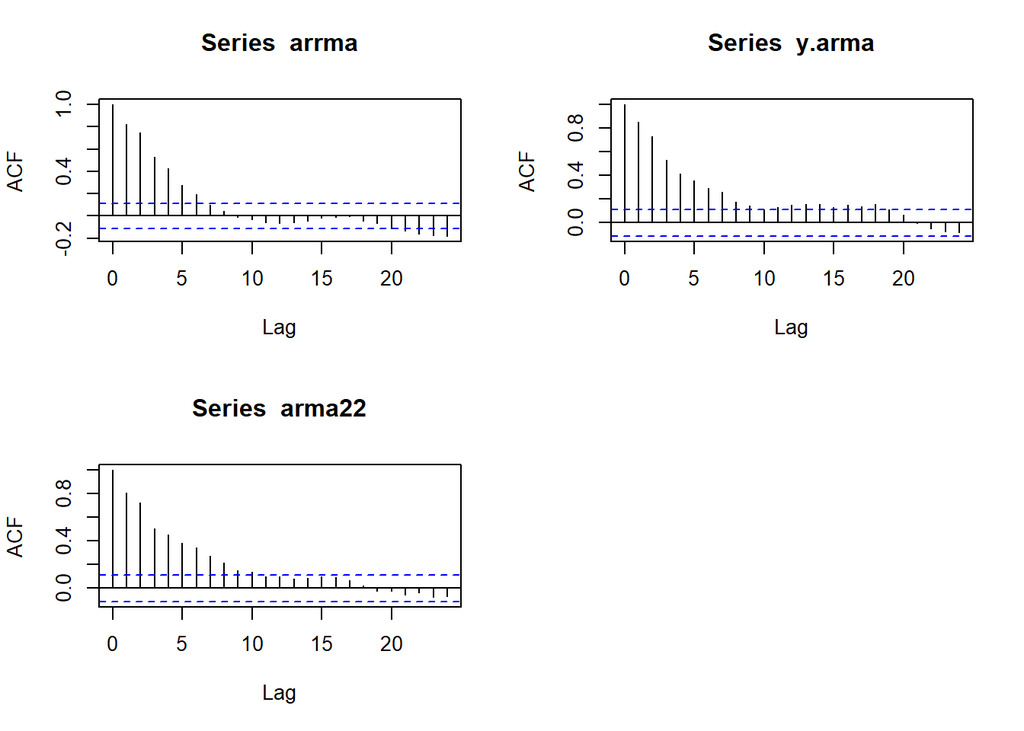

```r
par(mfrow = c(2, 2))
acf(arrma)
acf(y.arma)
acf(arma22)
par(mfrow = c(1, 1))
```

Berdasarkan plot ACF tersebut, terlihat bahwa model ARMA(2,2) hasil simulasi memiliki plot ACF yang *tails off*, sesuai dengan teori yang ada

### Plot PACF

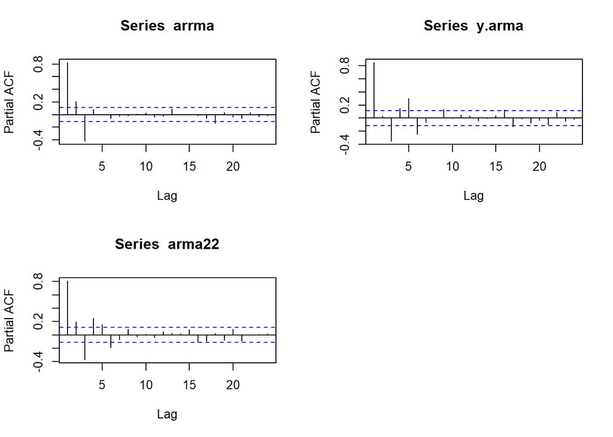

```r
par(mfrow = c(2, 2))
pacf(arrma)
pacf(y.arma)
pacf(arma22)
par(mfrow = c(1, 1))
```

### Plot EACF

```r
TSA::eacf(arrma)
```

```
## AR/MA
##   0 1 2 3 4 5 6 7 8 9 10 11 12 13
## 0 x x x x x x o o o o o  o  o  o
## 1 x x x x o x o o o o o  o  o  o
## 2 x x x x o x o o o o o  o  o  o
## 3 x o x o o o o o o o o  o  o  o
## 4 o o o o o o o o o o o  o  o  o
## 5 o x o o o o o o o o o  o  o  o
## 6 x o x o o o o o o o o  o  o  o
## 7 x o x o o o o o o o o  o  o  o
```

```r
TSA::eacf(y.arma)
```

```
## AR/MA
##   0 1 2 3 4 5 6 7 8 9 10 11 12 13
## 0 x x x x x x x x x o x  x  x  x
## 1 o x x x o o x x o x o  o  o  o
## 2 o x x x o o x o o x o  o  o  o
## 3 x x o x o o x o o x o  x  o  o
## 4 x x x o x o o x o x o  o  o  o
## 5 x x x x o o o x o x o  o  o  o
## 6 x o x o o o x o o o o  o  o  o
## 7 o o x o x o x o o o x  o  o  o
```

```r
TSA::eacf(arma22)
```

```
## AR/MA
##   0 1 2 3 4 5 6 7 8 9 10 11 12 13
## 0 x x x x x x x x x x o  o  o  o
## 1 x x x o o x o o o o o  o  o  o
## 2 x x x x o x o o o o o  o  o  o
## 3 x x x x o x o o o o o  o  o  o
## 4 x x o o x x o o o o o  o  o  o
## 5 x x x o x o o o o o o  o  o  o
## 6 x x x o x x o o o o o  o  o  o
## 7 x x o o o o o o o o o  o  o  o
```

### Scatterplot Antar Lag

#### Korelasi antara $Y_t$ dengan $Y_{t-1}$

```r
#Yt
yt_arma <- arma22[-1]
yt_arma
```

```
##   [1]  3.475154116  3.404648878  3.608188703  1.284827574  2.135939116
##   [6]  1.500836921  2.997412633  2.319480368  1.576000172  1.086852064
##  [11]  0.034431503 -0.069867181  1.934521929  0.504670795  2.186184030
##  [16] -0.175473722  1.104954519 -0.701350631 -0.706372683 -1.858997368
##  [21] -2.443984096  0.105417503 -1.123014463  0.967397576 -1.449485808
##  [26] -0.542644467 -2.260407439 -0.868309951 -1.462616464 -0.323738682
##  [31] -1.513964934 -0.677621513 -1.320295210 -1.167567166 -1.494259572
##  [36] -0.973692749 -0.210459069 -1.125925442 -0.351419057 -2.528526802
##  [41] -2.163979767 -3.092247229 -2.005483510 -1.891209945 -2.600324368
##  [46] -2.638196674 -3.335621035 -0.988776278 -0.858951631  0.504754967
##  [51]  0.113018576 -0.117541613  0.811037279  0.275518052  1.209066003
##  [56]  0.400411417  2.331010177  1.746493822  0.970682132 -0.457038117
##  [61]  0.670409426 -0.029465628  2.706158532  1.018132321  1.549468229
##  [66]  0.217013559 -0.400997030 -0.715767418 -1.392807782 -1.074465574
##  [71] -1.297941114 -1.263383858 -1.655533720 -1.807504298  0.279838637
```

[output cut: 45 more lines]

```r
#Yt-1
yt_1_arma <- arma22[-300]
yt_1_arma
```

```
##   [1]  3.929180780  3.475154116  3.404648878  3.608188703  1.284827574
##   [6]  2.135939116  1.500836921  2.997412633  2.319480368  1.576000172
##  [11]  1.086852064  0.034431503 -0.069867181  1.934521929  0.504670795
##  [16]  2.186184030 -0.175473722  1.104954519 -0.701350631 -0.706372683
##  [21] -1.858997368 -2.443984096  0.105417503 -1.123014463  0.967397576
##  [26] -1.449485808 -0.542644467 -2.260407439 -0.868309951 -1.462616464
##  [31] -0.323738682 -1.513964934 -0.677621513 -1.320295210 -1.167567166
##  [36] -1.494259572 -0.973692749 -0.210459069 -1.125925442 -0.351419057
##  [41] -2.528526802 -2.163979767 -3.092247229 -2.005483510 -1.891209945
##  [46] -2.600324368 -2.638196674 -3.335621035 -0.988776278 -0.858951631
##  [51]  0.504754967  0.113018576 -0.117541613  0.811037279  0.275518052
##  [56]  1.209066003  0.400411417  2.331010177  1.746493822  0.970682132
##  [61] -0.457038117  0.670409426 -0.029465628  2.706158532  1.018132321
##  [66]  1.549468229  0.217013559 -0.400997030 -0.715767418 -1.392807782
##  [71] -1.074465574 -1.297941114 -1.263383858 -1.655533720 -1.807504298
```

[output cut: 45 more lines]

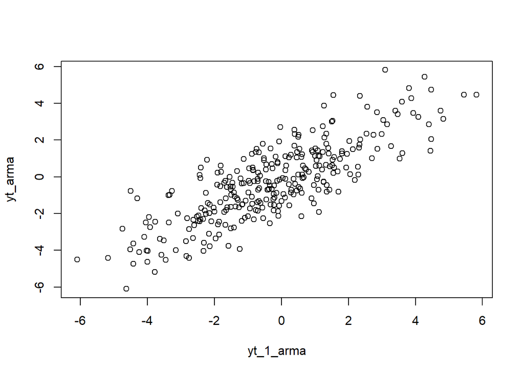

```r
plot(y=yt_arma,x=yt_1_arma)
```

Berdasarkan scatterplot tersebut, terlihat bahwa terdapat hubungan positif antara $Y_t$ dengan $Y_{t-1}$. Hal ini sesuai dengan teori yang ada

```r
cor(yt_arma,yt_1_arma)
```

```
## [1] 0.8129711
```

#### Korelasi antara $Y_t$ dengan $Y_{t-2}$

```r
#Yt
yt2_arma <- arma22[-c(1,2)]
yt2_arma
```

```
##   [1]  3.404648878  3.608188703  1.284827574  2.135939116  1.500836921
##   [6]  2.997412633  2.319480368  1.576000172  1.086852064  0.034431503
##  [11] -0.069867181  1.934521929  0.504670795  2.186184030 -0.175473722
##  [16]  1.104954519 -0.701350631 -0.706372683 -1.858997368 -2.443984096
##  [21]  0.105417503 -1.123014463  0.967397576 -1.449485808 -0.542644467
##  [26] -2.260407439 -0.868309951 -1.462616464 -0.323738682 -1.513964934
##  [31] -0.677621513 -1.320295210 -1.167567166 -1.494259572 -0.973692749
##  [36] -0.210459069 -1.125925442 -0.351419057 -2.528526802 -2.163979767
##  [41] -3.092247229 -2.005483510 -1.891209945 -2.600324368 -2.638196674
##  [46] -3.335621035 -0.988776278 -0.858951631  0.504754967  0.113018576
##  [51] -0.117541613  0.811037279  0.275518052  1.209066003  0.400411417
##  [56]  2.331010177  1.746493822  0.970682132 -0.457038117  0.670409426
##  [61] -0.029465628  2.706158532  1.018132321  1.549468229  0.217013559
##  [66] -0.400997030 -0.715767418 -1.392807782 -1.074465574 -1.297941114
##  [71] -1.263383858 -1.655533720 -1.807504298  0.279838637 -0.844039197
```

[output cut: 45 more lines]

```r
#Yt-1
yt2_1_arma <- arma22[-c(299,300)]
yt2_1_arma
```

```
##   [1]  3.929180780  3.475154116  3.404648878  3.608188703  1.284827574
##   [6]  2.135939116  1.500836921  2.997412633  2.319480368  1.576000172
##  [11]  1.086852064  0.034431503 -0.069867181  1.934521929  0.504670795
##  [16]  2.186184030 -0.175473722  1.104954519 -0.701350631 -0.706372683
##  [21] -1.858997368 -2.443984096  0.105417503 -1.123014463  0.967397576
##  [26] -1.449485808 -0.542644467 -2.260407439 -0.868309951 -1.462616464
##  [31] -0.323738682 -1.513964934 -0.677621513 -1.320295210 -1.167567166
##  [36] -1.494259572 -0.973692749 -0.210459069 -1.125925442 -0.351419057
##  [41] -2.528526802 -2.163979767 -3.092247229 -2.005483510 -1.891209945
##  [46] -2.600324368 -2.638196674 -3.335621035 -0.988776278 -0.858951631
##  [51]  0.504754967  0.113018576 -0.117541613  0.811037279  0.275518052
##  [56]  1.209066003  0.400411417  2.331010177  1.746493822  0.970682132
##  [61] -0.457038117  0.670409426 -0.029465628  2.706158532  1.018132321
##  [66]  1.549468229  0.217013559 -0.400997030 -0.715767418 -1.392807782
##  [71] -1.074465574 -1.297941114 -1.263383858 -1.655533720 -1.807504298
```

[output cut: 45 more lines]

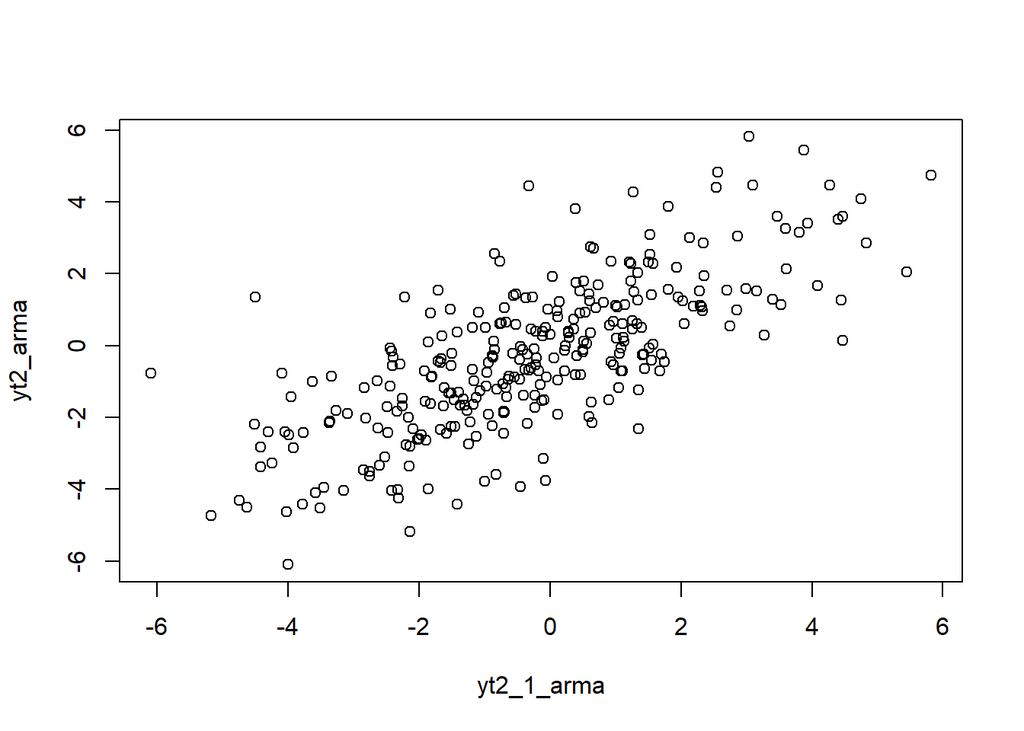

```r
plot(y=yt2_arma,x=yt2_1_arma)
```

```r
cor(yt2_arma,yt2_1_arma)
```

```
## [1] 0.7298301
```

#### Korelasi antara $Y_t$ dengan $Y_{t-3}$

```r
#Yt
yt3_arma <- arma22[-c(1,2,3)]
yt3_arma
```

```
##   [1]  3.608188703  1.284827574  2.135939116  1.500836921  2.997412633
##   [6]  2.319480368  1.576000172  1.086852064  0.034431503 -0.069867181
##  [11]  1.934521929  0.504670795  2.186184030 -0.175473722  1.104954519
##  [16] -0.701350631 -0.706372683 -1.858997368 -2.443984096  0.105417503
##  [21] -1.123014463  0.967397576 -1.449485808 -0.542644467 -2.260407439
##  [26] -0.868309951 -1.462616464 -0.323738682 -1.513964934 -0.677621513
##  [31] -1.320295210 -1.167567166 -1.494259572 -0.973692749 -0.210459069
##  [36] -1.125925442 -0.351419057 -2.528526802 -2.163979767 -3.092247229
##  [41] -2.005483510 -1.891209945 -2.600324368 -2.638196674 -3.335621035
##  [46] -0.988776278 -0.858951631  0.504754967  0.113018576 -0.117541613
##  [51]  0.811037279  0.275518052  1.209066003  0.400411417  2.331010177
##  [56]  1.746493822  0.970682132 -0.457038117  0.670409426 -0.029465628
##  [61]  2.706158532  1.018132321  1.549468229  0.217013559 -0.400997030
##  [66] -0.715767418 -1.392807782 -1.074465574 -1.297941114 -1.263383858
##  [71] -1.655533720 -1.807504298  0.279838637 -0.844039197  0.358874634
```

[output cut: 45 more lines]

```r
#Yt-1
yt3_1_arma <- arma22[-c(298,299,300)]
yt3_1_arma
```

```
##   [1]  3.92918078  3.47515412  3.40464888  3.60818870  1.28482757  2.13593912
##   [7]  1.50083692  2.99741263  2.31948037  1.57600017  1.08685206  0.03443150
##  [13] -0.06986718  1.93452193  0.50467079  2.18618403 -0.17547372  1.10495452
##  [19] -0.70135063 -0.70637268 -1.85899737 -2.44398410  0.10541750 -1.12301446
##  [25]  0.96739758 -1.44948581 -0.54264447 -2.26040744 -0.86830995 -1.46261646
##  [31] -0.32373868 -1.51396493 -0.67762151 -1.32029521 -1.16756717 -1.49425957
##  [37] -0.97369275 -0.21045907 -1.12592544 -0.35141906 -2.52852680 -2.16397977
##  [43] -3.09224723 -2.00548351 -1.89120994 -2.60032437 -2.63819667 -3.33562103
##  [49] -0.98877628 -0.85895163  0.50475497  0.11301858 -0.11754161  0.81103728
##  [55]  0.27551805  1.20906600  0.40041142  2.33101018  1.74649382  0.97068213
##  [61] -0.45703812  0.67040943 -0.02946563  2.70615853  1.01813232  1.54946823
##  [67]  0.21701356 -0.40099703 -0.71576742 -1.39280778 -1.07446557 -1.29794111
##  [73] -1.26338386 -1.65553372 -1.80750430  0.27983864 -0.84403920  0.35887463
##  [79] -0.11543761  0.73041956  0.39043329  1.69635694 -0.81759703 -0.24406896
##  [85] -1.21783872 -0.09688966 -2.13591426 -1.51341338 -2.81120256 -2.25402875
```

[output cut: 35 more lines]

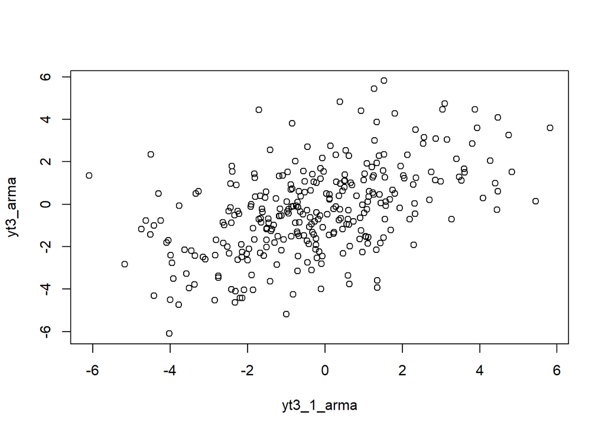

```r
plot(y=yt3_arma,x=yt3_1_arma)
```

```r
cor(yt3_arma,yt3_1_arma)
```

```
## [1] 0.5118455
```